Appendix C to the 2014 Utah Growth Model Report

Transition to the SAGE Assessment Program.

Damian W. Betebenner

Adam R. VanIwaarden

National Center for the Improvement  
of Educational Assessment (NCIEA)

June 2015

# 1 Introduction

In the 2013-2014 academic year, Utah transitioned from its previous Utah Criterion Referenced Tests (CRT) to the [Student Assessment of Growth and Excellence (SAGE)](http://www.schools.utah.gov/assessment/SAGE.aspx). The transition included numerous changes to the assessment system including the incorporation of new performance standards and moving to a vertical scale. The Utah SOE’s goal was to maintain SGP analyses across this transition. Based upon research and recommendations from the NCIEA, the calculation of SGPs across this transition was not likely to be problematic:

1. The current and previous assessments did not demonstrate pronounced floor or ceilings with large (>5%) of students obtaining the LOSS/HOSS.
2. The current and previous assessments would likely show similar correlations between current and prior scores seen on previous assessments.

Following SGP analysis of SAGE data using CRT data as priors, schools reported anomalies and this led to a larger investigation of results. The anomalies centered around deviations from previous results leading to questions about whether the SGPs calculated across the transition were valid.

Utah SOE asked the NCIEA to investigate further the validity of the SGP calculations. Validation began by looking at the two items mentioned above, and also included an investigation of the annual relationship of school-level median SGPs.

# 2 Ceiling/Floor Effects

The goodness of fit plots provided in the 2014 analyses confirm that no ceiling/floor effects were present that might distort the SGP analyses. All fit plots for the 2014 SGP analyses can be found in Appendix A of the 2014 Utah Growth Model Report. As an example, Figure C.1 shows the results for 8<sup>th</sup> grade ELA. Evidence of ceiling and floor effects would appear as inordinate numbers of high or low SGPs at the extremes of the prior scale scores. However, all analyses demonstrate a uniform distribution of SGPs as expected.

##### **Fig. C.1:** Goodness of Fit Plot for 2014 8<sup>th</sup> Grade ELA.

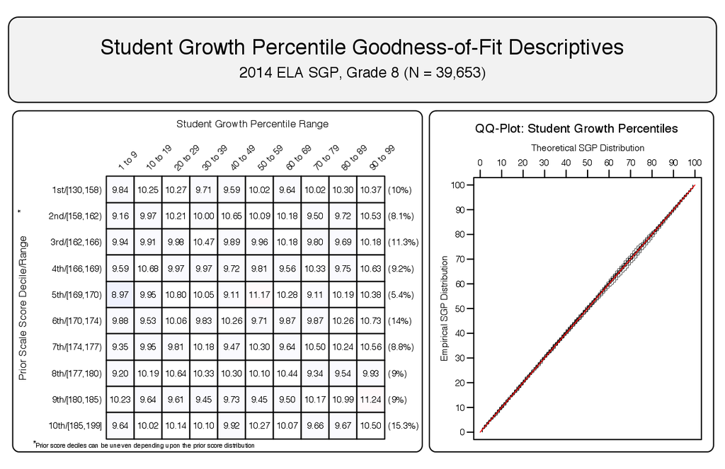

# 3 Test Score Correlations

Correlations between student level current and prior achievement scale scores were all high and similar to correlations seen previously between CRT administration. The correlations between these dependent and independent variables used in the regression analyses for 2011 - 2014 are shown in Tables 1 and 2, and are highly similar before and after the assessment transition.

| **Table 1:** Grade-Level CRT and SAGE Correlations Content Area | **Table 1:** Grade-Level CRT and SAGE Correlations Grade | **Table 1:** Grade-Level CRT and SAGE Correlations | **Table 1:** Grade-Level CRT and SAGE Correlations Academic Year 2011 | **Table 1:** Grade-Level CRT and SAGE Correlations Academic Year 2012 | **Table 1:** Grade-Level CRT and SAGE Correlations Academic Year 2013 | **Table 1:** Grade-Level CRT and SAGE Correlations Academic Year 2014 |
| --- | --- | --- | --- | --- | --- | --- |
| ELA | 4 |  | 0.75 | 0.74 | 0.74 | 0.75 |
|  | 5 |  | 0.76 | 0.76 | 0.75 | 0.75 |
|  | 6 |  | 0.77 | 0.77 | 0.77 | 0.76 |
|  | 7 |  | 0.76 | 0.77 | 0.76 | 0.75 |
|  | 8 |  | 0.73 | 0.77 | 0.76 | 0.77 |
|  | 9 |  | 0.72 | 0.74 | 0.77 | 0.76 |
|  | 10 |  | 0.72 | 0.73 | 0.76 | 0.75 |
|  | 11 |  | 0.75 | 0.75 | 0.76 | 0.75 |
| Mathematics | 4 |  | 0.77 | 0.78 | 0.77 | 0.79 |
|  | 5 |  | 0.80 | 0.81 | 0.80 | 0.79 |
|  | 6 |  | 0.80 | 0.80 | 0.82 | 0.81 |
|  | 7 |  | 0.71 | 0.80 | 0.80 | 0.80 |
| Science | 5 |  | 0.76 | 0.76 | 0.76 | 0.74 |
|  | 6 |  | 0.76 | 0.76 | 0.78 | 0.76 |
|  | 7 |  | 0.78 | 0.76 | 0.77 | 0.77 |
|  | 8 |  | 0.80 | 0.81 | 0.80 | 0.80 |

| **Table 2:** EOCT Subject Correlations Before and After SAGE Transition. Content Area | **Table 2:** EOCT Subject Correlations Before and After SAGE Transition. | **Table 2:** EOCT Subject Correlations Before and After SAGE Transition. Academic Year 2011 | **Table 2:** EOCT Subject Correlations Before and After SAGE Transition. Academic Year 2012 | **Table 2:** EOCT Subject Correlations Before and After SAGE Transition. Academic Year 2013 | **Table 2:** EOCT Subject Correlations Before and After SAGE Transition. Academic Year 2014 |
| --- | --- | --- | --- | --- | --- |
| Earth Science |  | 0.79 | 0.80 | 0.79 | 0.76 |
| Biology |  | 0.79 | 0.80 | 0.79 | 0.77 |
| Chemistry |  | 0.73 | 0.73 | 0.75 | 0.73 |
| Physics |  | 0.70 | 0.67 | 0.68 | 0.68 |

# 4 School-Level Median SGPs

##### **Fig. C.2:** Median SGP by Year and Content Area.

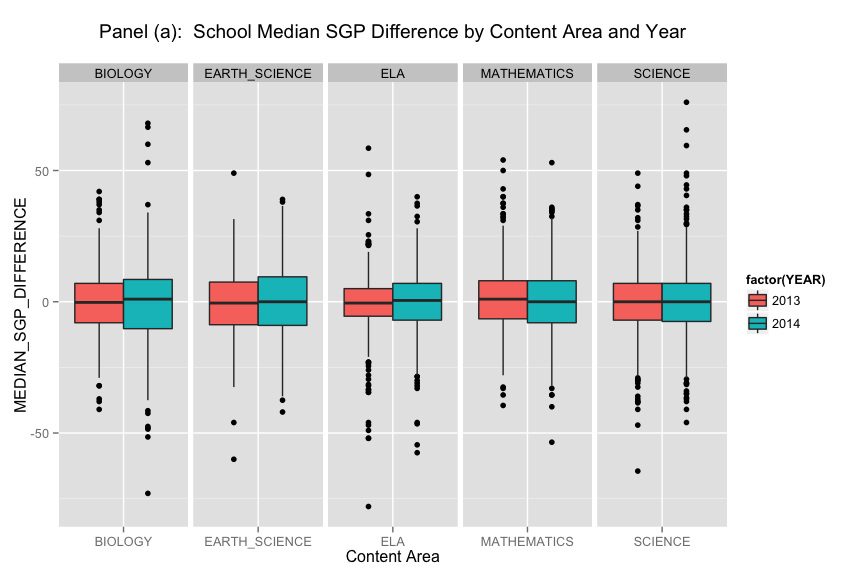

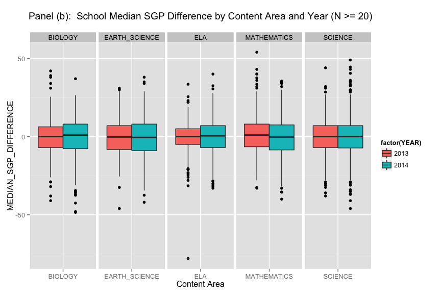

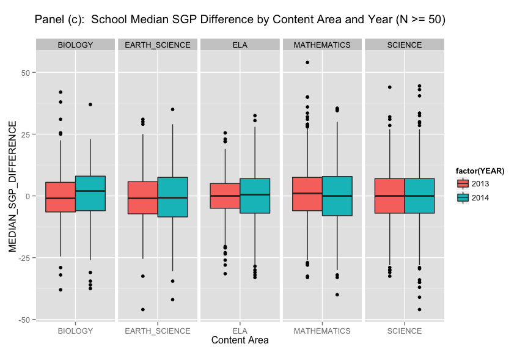

The bubblePlots shown in Figures C.3 and C.4 show the 2013 school median SGP versus the 2014 school median SGP. Bubbles in the upper left/lower right of the charts correspond to those with larger differences.

##### **Fig. C.3:** Median SGP by Year and Content Area Bubble Plots for Grade-Level SAGE.

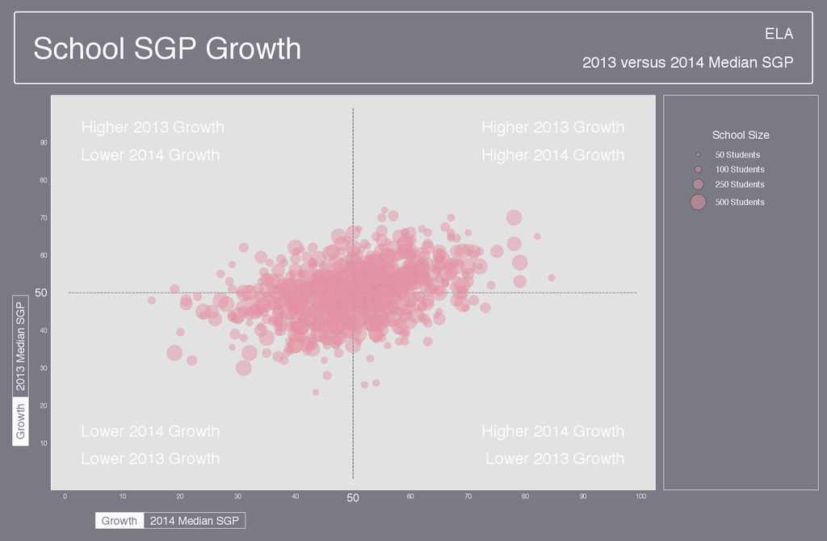

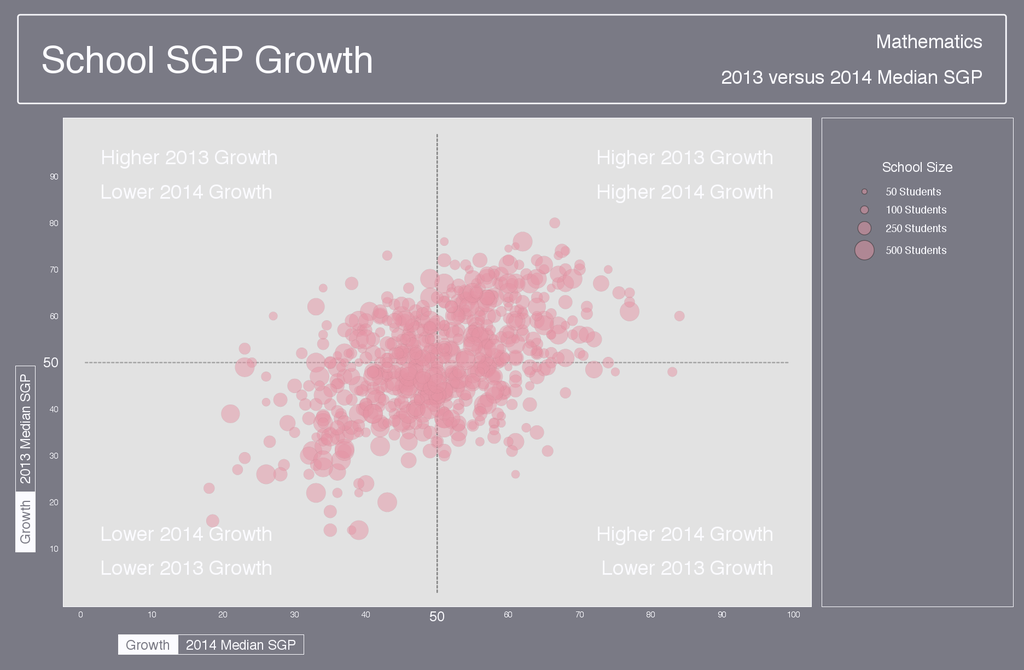

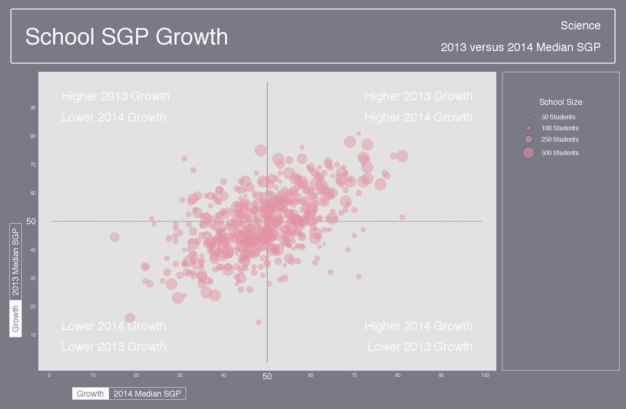

##### **Fig. C.4:** Median SGP by Year and Content Area Bubble Plots for End-of-Course Tests (EOCT).

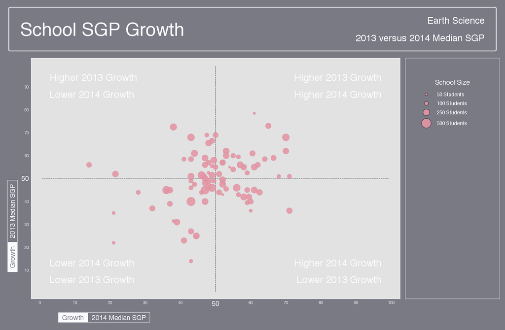

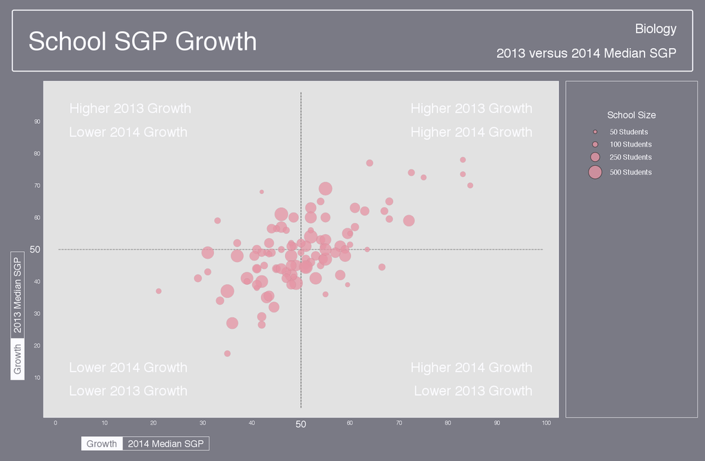

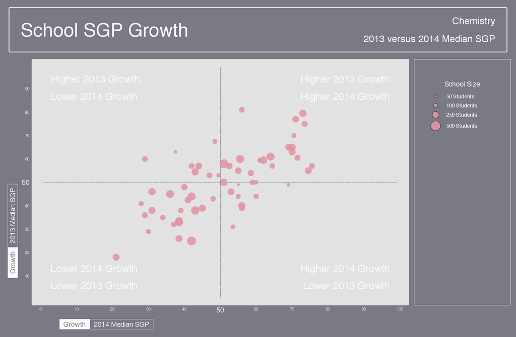

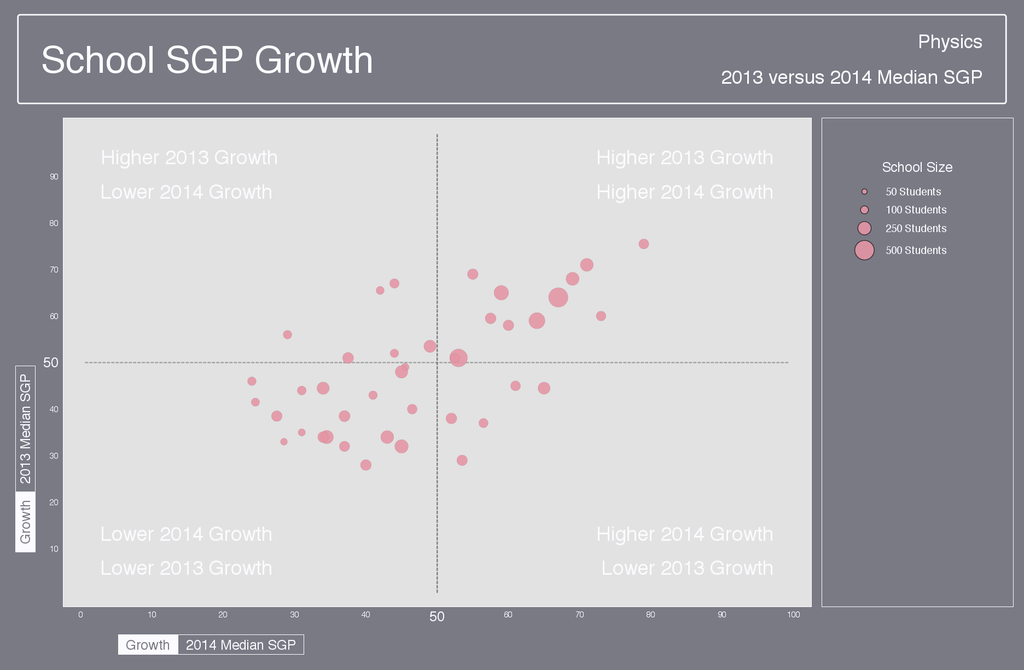

To look more closely at specific outliers, Figure C.5 show student level SGP distribution by grade and content area across years. The box plot median indicates the median SGP for that grade by content area by year set of SGPs.

##### **Fig. C.5:** School SGP distribution by content area, year, and grade with student count.

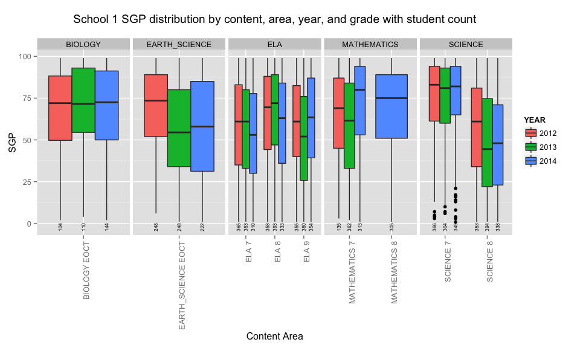

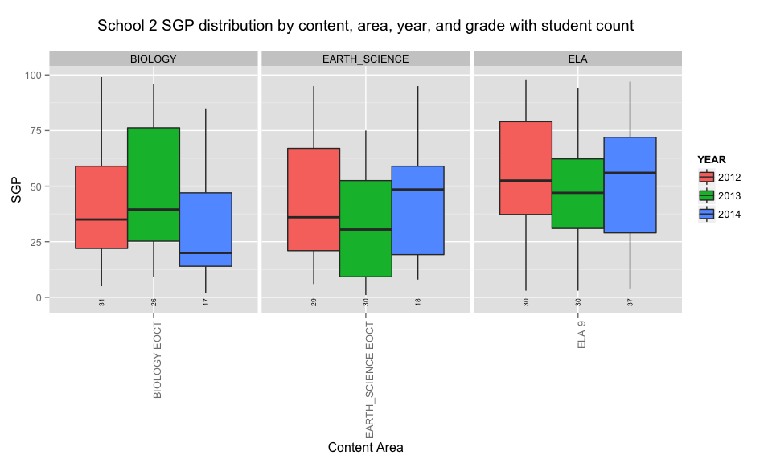

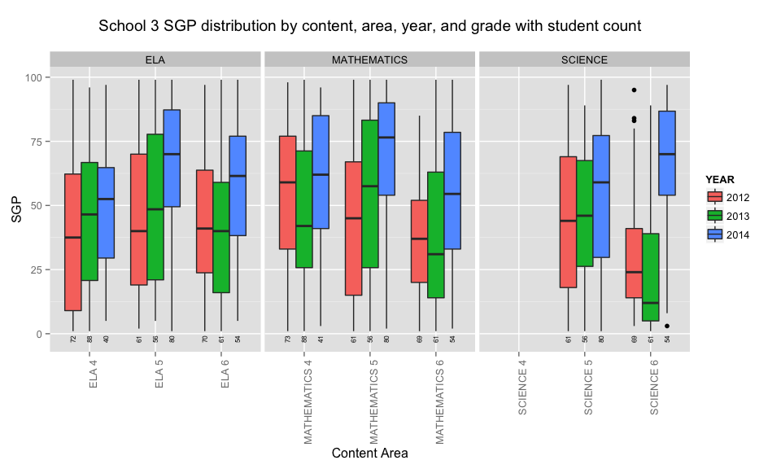

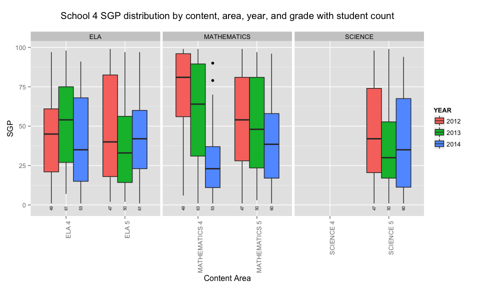

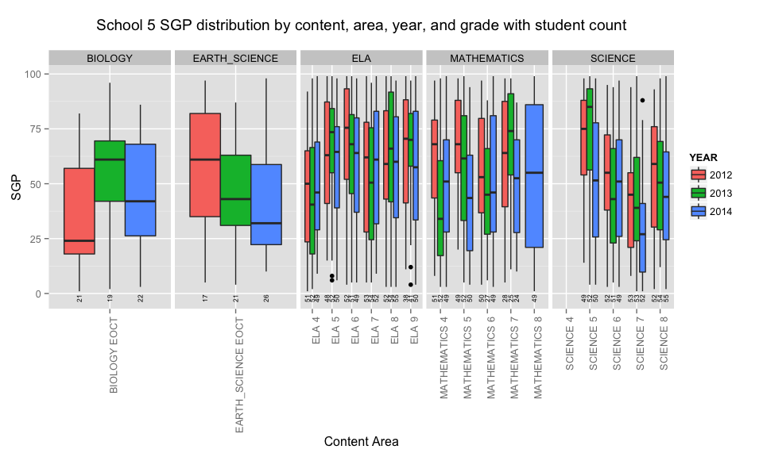

Overall, the results confirm that the SGP analyses are valid and not invalidated due to the transition from the CRT to SAGE assessments. However, it is likely that the transition to new assessments and standards is reflected in the results just discussed with some schools making the transition much better than others. Next steps, particularly for schools with big changes, is to investigate exactly what content areas and grades led to these changes and reflect upon potential root causes for the change.